# Ashdod-Yam mudbrick analysis

Uine Kailamäki

### pXRF

From literature we can identify three rough classes of elements that could be used to analyze mudbricks from pXRF results:

Good: Rb, Sr, Y, Zr, Nb, Th, Pb, Cu, Zn, Fe  
Neutral: V, Cr, Co, Ni, Ca, Ti  
Bad: Na, P, Ba (+ Ca, Al)

#### Data preparation

```r
# Libraries
library(openxlsx);
library(dplyr);
```

```r
library(ggfortify); # PCA autoplots
library(FactoMineR); # Fast PCA graphs
library(dendextend); # Dendrograms
# Read the raw data
pxrf <- read.xlsx("data/pxrf_AY.xlsx", sep=";")

# Remove any rows containing words 'ERROR' or 'TEST'
pxrf <- filter(pxrf, !grepl('TEST', Sample))
pxrf <- filter(pxrf, !grepl('ERROR', Sample))

# Remove unused columns
pxrf <- pxrf %>%
        select(-Site) %>%
        select(-'Other;name') %>%
        select(-'File;#') %>%
        select(-DateTime) %>%
        select(-Application) %>%
        select(-Method) %>%
        select(-ElapsedTime) %>%
        select(-'Cal;Check')

# Coercing "< LOD" -results to NA:s
pxrf[4:93] <- pxrf[4:93] %>% mutate_if(is.character,as.numeric)
```

[output not shown]

[output cut: 8 more lines]

[output not shown]

```r
# Averaging results by "Sample", "Area" and "Type" columns
pxrf_averaged <- aggregate(pxrf, by = list(pxrf$Sample, pxrf$Area, pxrf$Type), FUN = mean)
```

[output not shown]

[output cut: 364 more lines]

[output not shown]

```r
# Removing old (now empty) columns
pxrf_averaged <- pxrf_averaged %>% select(-Sample)
pxrf_averaged <- pxrf_averaged %>% select(-Area)
pxrf_averaged <- pxrf_averaged %>% select(-Type)

# Assigning sample names as new row names
rownames(pxrf_averaged) <- pxrf_averaged$Group.1
pxrf_averaged <- pxrf_averaged %>% select(-Group.1)

# Renaming the other two newly created groups back to "Type" and "Area"
names(pxrf_averaged)[names(pxrf_averaged) == "Group.2"] <- "Area"
names(pxrf_averaged)[names(pxrf_averaged) == "Group.3"] <- "Type"

# Removing error columns from the scaled analysis data set
pxrf_scaled <- pxrf_averaged %>% select(-ends_with("Err"))

# Scaling the data with standard z-score method
pxrf_scaled[3:47] <- scale(pxrf_scaled[3:47])

# Removing columns that only contain NA values
all_na <- function(x) any(!is.na(x))
pxrf_all <- pxrf_scaled %>% select_if(all_na)
```

**pxrf_averaged**: All averaged data including averaged errors (Uine’s note: for later use)

```r
colnames(pxrf_averaged)
```

```
##  [1] "Area"      "Type"      "MgO"       "MgO;Err"   "Al2O3"     "Al2O3;Err"
##  [7] "SiO2"      "SiO2;Err"  "P2O5"      "P2O5;Err"  "S"         "S;Err"
## [13] "Cl"        "Cl;Err"    "K2O"       "K2O;Err"   "CaO"       "CaO;Err"
## [19] "Ti"        "Ti;Err"    "V"         "V;Err"     "Cr"        "Cr;Err"
## [25] "Mn"        "Mn;Err"    "Fe"        "Fe;Err"    "Co"        "Co;Err"
## [31] "Ni"        "Ni;Err"    "Cu"        "Cu;Err"    "Zn"        "Zn;Err"
## [37] "As"        "As;Err"    "Se"        "Se;Err"    "Rb"        "Rb;Err"
## [43] "Sr"        "Sr;Err"    "Y"         "Y;Err"     "Zr"        "Zr;Err"
## [49] "Nb"        "Nb;Err"    "Mo"        "Mo;Err"    "Rh"        "Rh;Err"
## [55] "Pd"        "Pd;Err"    "Ag"        "Ag;Err"    "Cd"        "Cd;Err"
## [61] "Sn"        "Sn;Err"    "Sb"        "Sb;Err"    "Ba"        "Ba;Err"
## [67] "La"        "La;Err"    "Ce"        "Ce;Err"    "Hf"        "Hf;Err"
## [73] "Ta"        "Ta;Err"    "W"         "W;Err"     "Pt"        "Pt;Err"
## [79] "Au"        "Au;Err"    "Hg"        "Hg;Err"    "Tl"        "Tl;Err"
## [85] "Pb"        "Pb;Err"    "Bi"        "Bi;Err"    "Th"        "Th;Err"
## [91] "U"         "U;Err"
```

**pxrf_all**: All elements (the numbers below are the amount of NA values)

```r
colSums(is.na(pxrf_all))
```

```
##  Area  Type   MgO Al2O3  SiO2  P2O5     S    Cl   K2O   CaO    Ti     V    Mn
##     0     0     1     0     0     0    43     1     0     0     0    28     0
##    Fe    Ni    Cu    Zn    As    Rb    Sr     Y    Zr    Nb    Ba
##     0     1     0     0    27     0     0     2     0    31    45
```

**pxrf_final**: Final analysis data set with only the selected elements

```r
# Dropping the dubious elements and elements with too many NA values
pxrf_final <- pxrf_all %>%
        select(-Al2O3) %>%
        select(-CaO) %>%
        select(-SiO2) %>%
        select(-Cl) %>%
        select(-K2O) %>%
        select(-Ni) %>%
        select(-P2O5) %>%
        select(-S) %>%
        select(-V) %>%
        select(-As) %>%
        select(-Nb) %>%
        select(-Ba) %>%
        select(-MgO) %>%
        select(-Cu)

# Transforming remaining NA values to zeros for analysis
pxrf_final[is.na(pxrf_final)] <- 0

# Final analysis data set
colnames(pxrf_final)
```

```
##  [1] "Area" "Type" "Ti"   "Mn"   "Fe"   "Zn"   "Rb"   "Sr"   "Y"    "Zr"
```

#### pXRF: K means cluster analysis

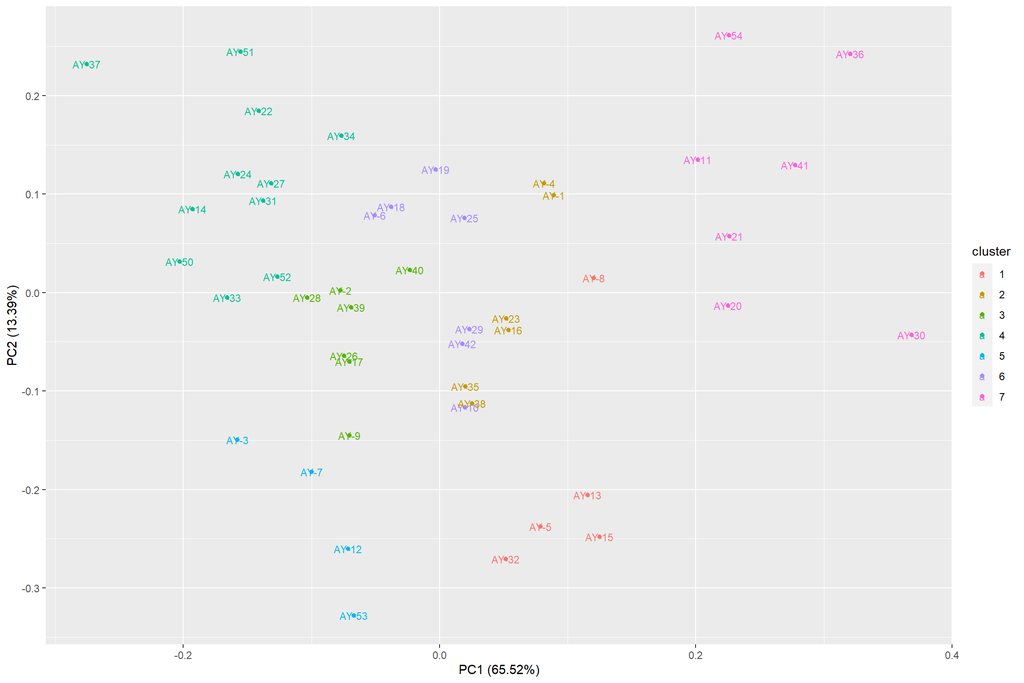

```r
# PC autoplot with K-means clusters
set.seed(1)
autoplot(kmeans(pxrf_final[3:10], 7), data = pxrf_final, label = TRUE, label.size = 3)
```

#### pXRF: PCA

**PCA with final elements**:

```r
# Elements
colnames(pxrf_final[3:10])
```

```
## [1] "Ti" "Mn" "Fe" "Zn" "Rb" "Sr" "Y"  "Zr"
```

```r
# PCA analysis
pca_1 <- prcomp(pxrf_final[3:10])
summary(pca_1)
```

```
## Importance of components:
##                           PC1    PC2     PC3     PC4     PC5     PC6     PC7
## Standard deviation     2.2832 1.0323 0.85066 0.66341 0.46658 0.44657 0.23581
## Proportion of Variance 0.6552 0.1339 0.09095 0.05531 0.02736 0.02506 0.00699
## Cumulative Proportion  0.6552 0.7891 0.88007 0.93538 0.96274 0.98781 0.99480
##                           PC8
## Standard deviation     0.2035
## Proportion of Variance 0.0052
## Cumulative Proportion  1.0000
```

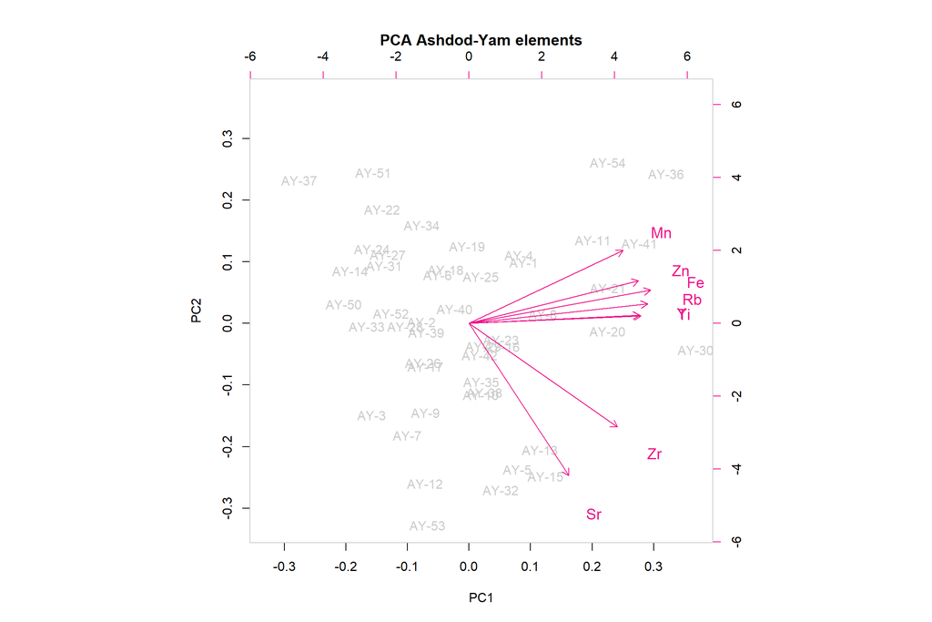

```r
# PCA plots
biplot(pca_1, choices = 1:2, cex = c(1, 1.2), col = c("grey80", "deeppink2"), main = "PCA Ashdod-Yam elements")
```

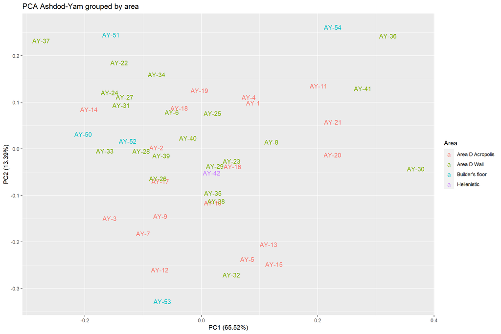

```r
autoplot(pca_1, data=pxrf_final, colour='Area', shape = FALSE, label = TRUE,  main = "PCA Ashdod-Yam grouped by area")
```

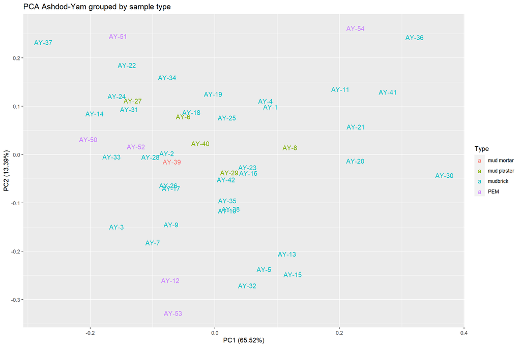

```r
autoplot(pca_1, data=pxrf_final, colour='Type', shape = FALSE, label = TRUE,  main = "PCA Ashdod-Yam grouped by sample type")
```

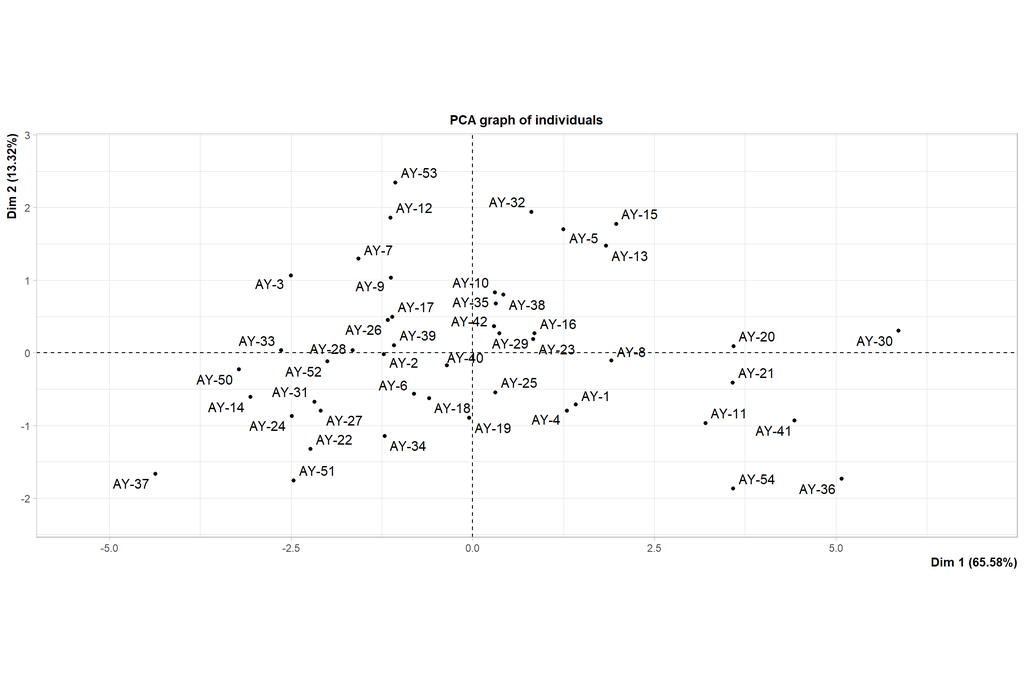

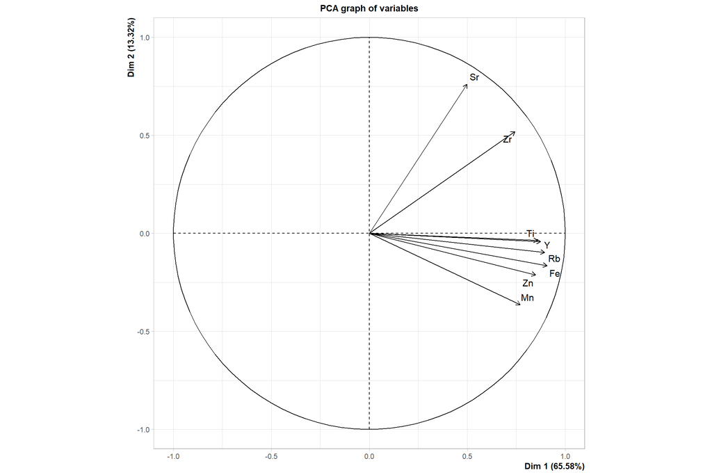

```
## **Results for the Principal Component Analysis (PCA)**
## The analysis was performed on 47 individuals, described by 8 variables
## *The results are available in the following objects:
##
##    name               description
## 1  "$eig"             "eigenvalues"
## 2  "$var"             "results for the variables"
## 3  "$var$coord"       "coord. for the variables"
## 4  "$var$cor"         "correlations variables - dimensions"
## 5  "$var$cos2"        "cos2 for the variables"
## 6  "$var$contrib"     "contributions of the variables"
## 7  "$ind"             "results for the individuals"
## 8  "$ind$coord"       "coord. for the individuals"
## 9  "$ind$cos2"        "cos2 for the individuals"
## 10 "$ind$contrib"     "contributions of the individuals"
## 11 "$call"            "summary statistics"
## 12 "$call$centre"     "mean of the variables"
## 13 "$call$ecart.type" "standard error of the variables"
## 14 "$call$row.w"      "weights for the individuals"
## 15 "$call$col.w"      "weights for the variables"
```

```r
PCA(pxrf_final[3:10])
```